# BIOS 667 - Lecture 15: GLMM Random Slopes (Ch. 14)

Fitzmaurice, Laird & Ware (2011) - Applied Longitudinal Data Analysis

Naim Rashid

## Lecture Objectives

- Extend random-intercept GLMMs to include **random slopes**
- Specify random slope models for **binary** and **count** outcomes
- Interpret the **variance-covariance structure** $G$ of random effects
- Compute and interpret **empirical Bayes predictors** for subject-specific inference
- Understand computational approaches: **Laplace**, **adaptive Gauss-Hermite quadrature**
- Apply model selection criteria for comparing GLMMs

## A Note on FLW Chapter Numbering

**Note**

**This lecture’s content is FLW Chapter 14** (Generalized Linear Mixed Effects Models): random-slope specification, subject-specific interpretation, empirical Bayes prediction, and adaptive Gaussian quadrature, including the very epilepsy Poisson random-slope model used here (FLW Examples, Sec. 14.3-14.7, Tables 14.5-14.8).

The course slot is “Lecture 15,” but FLW’s **physical Chapter 15** is a different topic: *Approximate Methods of Estimation* (penalized and marginal quasi-likelihood, PQL/MQL). We touch PQL/MQL and the Laplace approximation only briefly, and flag them as FLW Ch. 15 material when we do.

## Roadmap

**Part I (Day 1, ~75 min):** specification and interpretation

| Part | Topic |
| --- | --- |
| I | From Random Intercepts to Random Slopes |
| II | Model Specification for Discrete Outcomes |
| III | Interpretation of Random Slope Variance |
| IV | Prediction and Empirical Bayes Predictors |

**Part II (Day 2, ~75 min):** computation, selection, full case study

| Part | Topic |
| --- | --- |
| V | Computational Considerations |
| VI | Model Selection and Comparison |
| VII | Applied Case Study: Epilepsy Data |

## Notation reference

| Symbol | Meaning |
| --- | --- |
| $Y_{ij}$ | response for subject $i$ at occasion $j$ (scalar) |
| $\mathbf{Y}_i$ | response vector for subject $i$ $(n_i \times 1)$ |
| $\mathbf{X}_i,\ \boldsymbol\beta$ | fixed-effect design $n_i \times p$ and coefficients |
| $\mathbf{Z}_i,\ \mathbf{b}_i$ | random-effect design and random effects, $\mathbf{b}_i \sim N(0, G)$ |
| $G$ | between-subject random-effects covariance (FLW’s letter, Ch. 8) |
| $R_i$ | within-subject residual covariance, $\boldsymbol\varepsilon_i \sim N(0, R_i)$ |
| $\Sigma_i = \mathbf{Z}_i G \mathbf{Z}_i^\top + R_i$ | marginal (total) covariance $\operatorname{Cov}(\mathbf{Y}_i)$ for subject $i$ |
| $\rho$ | correlation parameter (AR(1), exchangeable) |

Indices: $i$ subject $1,\dots,N$; $j$ occasion/time $1,\dots,n_i$ ($n$ when balanced); $k$ state (transition models); $g$ group. **Bold** = vector or matrix.

## Notation (this lecture)

| Symbol | Meaning |
| --- | --- |
| $G = \begin{pmatrix} \sigma_0^2 & \sigma_{01} \\ \sigma_{01} & \sigma_1^2 \end{pmatrix}$ | $2\times2$ random-effects covariance (intercept, slope) |
| $\sigma_0^2,\ \sigma_1^2$ | between-subject variance of random intercept, random slope |
| $\sigma_{01}$ | intercept-slope covariance; $\rho_{01} = \sigma_{01}/(\sigma_0\sigma_1)$ |
| $\hat{\mathbf{b}}_i = E[\mathbf{b}_i \mid \mathbf{Y}_i; \hat{\boldsymbol\beta}, \hat G]$ | empirical Bayes (EB) predictor of subject $i$’s random effects |
| $v(\mu)$ | GLM mean-variance function (scalar) |

## Part I: From Random Intercepts to Random Slopes

## Review: Random Intercept GLMM

In Lecture 14, we modeled:

$$g(E[Y_{ij}|\mathbf{b}_i]) = X_{ij}\beta + b_{0i}$$

where $b_{0i} \sim N(0, \sigma_0^2)$

**Limitation:** All subjects share the same covariate effects (slopes).

## Why Random Slopes?

In longitudinal studies, subjects often differ not just in **baseline levels** but also in **rates of change**.

| Aspect | Random Intercept | Random Slope |
| --- | --- | --- |
| Subject heterogeneity | Baseline only | Baseline + trajectory |
| Covariate effect | Same for all subjects | Varies across subjects |
| Correlation structure | Induced by shared intercept | More flexible |

## Motivating Example: Epilepsy Trial

- 59 epileptic patients randomized to progabide vs placebo
- Baseline seizure count over an 8-week interval, then counts at 4 post-baseline visits (2-week intervals)
- Patients may differ in:
  - **Baseline seizure rate** (random intercept)
  - **Response to treatment over time** (random slope for time)

**Note**

This is FLW’s Ch. 14 case study (Sec. 14.7, Tables 14.5-14.8; Thall and Vail 1990; Leppik et al. 1987). We carry it through to the full worked analysis in Part VII.

## Random Slope Model: Concept

$$g(\mu_{ij}) = X_{ij}\beta + b_{0i} + b_{1i}\, t_{ij}$$

where:

- $b_{0i}$ = subject-specific intercept deviation
- $b_{1i}$ = subject-specific slope deviation for time $t_{ij}$ (a column of $Z_{ij}$)

$$\mathbf{b}_i = \begin{pmatrix} b_{0i} \\ b_{1i} \end{pmatrix} \sim N\left(\begin{pmatrix} 0 \\ 0 \end{pmatrix}, G = \begin{pmatrix} \sigma_0^2 & \sigma_{01} \\ \sigma_{01} & \sigma_1^2 \end{pmatrix}\right)$$

## What the Covariance Matrix G Captures

$$G = \begin{pmatrix} \sigma_0^2 & \sigma_{01} \\ \sigma_{01} & \sigma_1^2 \end{pmatrix}$$

| Parameter | Interpretation |
| --- | --- |
| $\sigma_0^2$ | Between-subject variance in intercepts |
| $\sigma_1^2$ | Between-subject variance in slopes |
| $\sigma_{01}$ | Covariance between intercepts and slopes |
| $\rho_{01} = \sigma_{01}/(\sigma_0 \sigma_1)$ | Correlation between intercepts and slopes |

## Correlation Interpretation

| Sign of $\rho_{01}$ | Interpretation |
| --- | --- |
| $\rho_{01} > 0$ | Subjects with higher baseline also have steeper slopes |
| $\rho_{01} < 0$ | Subjects with higher baseline have flatter slopes |
| $\rho_{01} = 0$ | Intercepts and slopes are independent |

This correlation **can be** scientifically meaningful, but it is often weak and hard to estimate.

**Warning**

## Part II: Model Specification for Discrete Outcomes

## Binary Outcome: Random Slope Logistic GLMM

**Model:**

$$\log\left(\frac{P(Y_{ij}=1|b_i)}{1-P(Y_{ij}=1|b_i)}\right) = X_{ij}\beta + b_{0i} + b_{1i} \cdot \text{time}_{ij}$$

**Key features:**

- Subject-specific log-odds trajectory
- Coefficients $\beta$ are **conditional** on $(b_{0i}, b_{1i})$
- Allows subjects to have different treatment response rates

## Count Outcome: Random Slope Poisson GLMM

**Model:**

$$\log(E[Y_{ij}|\mathbf{b}_i]) = X_{ij}\beta + b_{0i} + b_{1i} \cdot t_{ij}$$

**For epilepsy data:** allows each patient to have:

- Own baseline seizure rate (intercept)
- Own time trend (slope)

## General Random Slope GLMM Structure

**Level 1** (observation level):

$$Y_{ij} | \mathbf{b}_i \sim \text{EF}(\mu_{ij}, \phi), \quad g(\mu_{ij}) = X_{ij}\beta + Z_{ij} \mathbf{b}_i$$

**Level 2** (subject level):

$$\mathbf{b}_i \sim N_q(0, G)$$

where $q$ = dimension of random effects vector.

**Note**

$\text{EF}(\mu,\phi)$ is the exponential family from Ch. 11 (mean $\mu$, dispersion $\phi$, variance $\phi\, v(\mu)$). For the Poisson count outcome, $g^{-1}=\exp$ and $\phi=1$ (no separate dispersion parameter), so do not look for a $\phi$ estimate in the output.

## Design Matrices for Random Slopes

**Fixed effects design:** $X_i$ (typically includes all predictors)

**Random effects design:** $Z_i$ (subset of $X_i$)

| Common specification | $Z_i$ columns |
| --- | --- |
| Random intercept only | 1 (constant) |
| Random intercept + time slope | 1, time |
| Random intercept + treatment slope | 1, treatment indicator |

## Datasets and Packages (load cold)

**Dataset:** `epilepsy.txt` (FLW Ch. 14 case study). Load local first, else download from the FLW site.

**Packages:** `dplyr`, `tidyr`, `ggplot2`, `lme4` (fitting), `broom.mixed` (tidy output), `patchwork` (plot layout), `glmmTMB` (negative binomial mixed model, called qualified). `MASS` is also called qualified (`MASS::mvrnorm`) so it does not mask `dplyr::select`.

```r
suppressPackageStartupMessages({
  library(dplyr)
  library(tidyr)
  library(ggplot2)
  library(lme4)
  library(broom.mixed)
  library(patchwork)
})
theme_set(theme_minimal(base_size = 16))
```

## Datasets and Packages (load cold)

## Load Epilepsy Data (download fallback)

```r
# Local first, else download from the FLW site (CLAUDE.md data-loading pattern)
data_url  <- "https://content.sph.harvard.edu/fitzmaur/ala2e/epilepsy.txt"
data_file <- "../../data/epilepsy.txt"
if (!file.exists(data_file)) {
  dir.create(dirname(data_file), showWarnings = FALSE, recursive = TRUE)
  download.file(data_url, data_file)
}

# The file has a 36-line comment header; columns are wide (one row per patient)
epi_raw <- read.table(data_file, skip = 36, header = FALSE,
                      col.names = c("id", "trt", "age", "base",
                                    "y1", "y2", "y3", "y4"))

# Reshape to long format
epi_long <- epi_raw %>%
  pivot_longer(cols = y1:y4, names_to = "visit_num", values_to = "seizures") %>%
  mutate(
    visit = as.integer(gsub("y", "", visit_num)),
    time = (visit - 1) * 2,  # weeks since first post-baseline visit
    trt = factor(trt, levels = c(0, 1), labels = c("Placebo", "Progabide")),
    log_base = log(base / 4),  # log of baseline rate per 2-week period
    age_c = age - mean(age)    # centered age
  )

glimpse(epi_long)
```

**Warning**

**Instructor variant (flag for the class).** FLW’s Ch. 14 model (p. 422, Table 14.5) includes the **baseline period as period 0** with an **offset** $\log(T_{ij})$ (8 weeks baseline vs 2 weeks follow-up) and a **binary** Time indicator. Our reshaping keeps only the 4 post-baseline visits, uses **continuous** `visit`, and adds $\log(\text{base}/4)$ and centered age as covariates with **no offset**. This is the standard Thall-Vail / Breslow-Clayton epilepsy parameterization, a legitimate variant, but it is not FLW’s exact Ch. 14 model. We reproduce FLW’s offset model in the case study.

## Load Epilepsy Data (download fallback)

```
Rows: 236
Columns: 10
$ id        <int> 1, 1, 1, 1, 2, 2, 2, 2, 3, 3, 3, 3, 4, 4, 4, 4, 5, 5, 5, 5, …
$ trt       <fct> Placebo, Placebo, Placebo, Placebo, Placebo, Placebo, Placeb…
$ age       <int> 31, 31, 31, 31, 30, 30, 30, 30, 25, 25, 25, 25, 36, 36, 36, …
$ base      <int> 11, 11, 11, 11, 11, 11, 11, 11, 6, 6, 6, 6, 8, 8, 8, 8, 66, …
$ visit_num <chr> "y1", "y2", "y3", "y4", "y1", "y2", "y3", "y4", "y1", "y2", …
$ seizures  <int> 5, 3, 3, 3, 3, 5, 3, 3, 2, 4, 0, 5, 4, 4, 1, 4, 7, 18, 9, 21…
$ visit     <int> 1, 2, 3, 4, 1, 2, 3, 4, 1, 2, 3, 4, 1, 2, 3, 4, 1, 2, 3, 4, …
$ time      <dbl> 0, 2, 4, 6, 0, 2, 4, 6, 0, 2, 4, 6, 0, 2, 4, 6, 0, 2, 4, 6, …
$ log_base  <dbl> 1.0116009, 1.0116009, 1.0116009, 1.0116009, 1.0116009, 1.011…
$ age_c     <dbl> 2.1694915, 2.1694915, 2.1694915, 2.1694915, 1.1694915, 1.169…
```

## Explore the Data Structure

```r
# Summary by treatment
epi_long %>%
  group_by(trt, visit) %>%
  summarise(
    mean_seizures = mean(seizures),
    sd_seizures = sd(seizures),
    median = median(seizures),
    n = n(),
    .groups = "drop"
  )
```

## Explore the Data Structure

```
# A tibble: 8 × 6
  trt       visit mean_seizures sd_seizures median     n
  <fct>     <int>         <dbl>       <dbl>  <dbl> <int>
1 Placebo       1          9.36       10.1     5      28
2 Placebo       2          8.29        8.16    4.5    28
3 Placebo       3          8.79       14.7     5      28
4 Placebo       4          8           7.61    5      28
5 Progabide     1          8.58       18.2     4      31
6 Progabide     2          8.42       11.9     5      31
7 Progabide     3          8.13       13.9     4      31
8 Progabide     4          6.74       11.3     4      31
```

## Visualize Individual Trajectories

```r
ggplot(epi_long, aes(x = visit, y = seizures, group = id, color = trt)) +
  geom_line(alpha = 0.4) +
  stat_summary(aes(group = trt), fun = mean, geom = "line",
               linewidth = 1.5, linetype = "dashed") +
  facet_wrap(~trt) +
  labs(x = "Visit (2-week periods)", y = "Seizure Count",
       title = "Individual Seizure Trajectories by Treatment") +
  scale_y_log10() +
  theme(legend.position = "none")
```

## Visualize Individual Trajectories

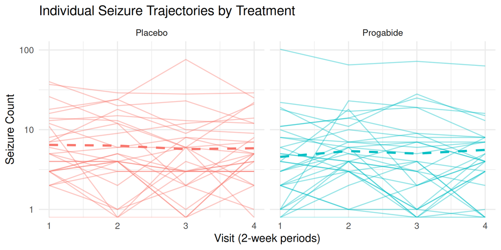

## Key Observations

- **High variability** between subjects (need random intercepts)
- Some subjects show **decreasing** trends, others **increasing** (need random slopes?)
- Potential **outliers** with very high counts (overdispersion concern)
- Treatment effect may **evolve** over time

## Part III: Interpretation of Random Slope Variance

## What Does $\sigma_1^2$ Tell Us?

$\sigma_1^2$ = variance of subject-specific slopes (on the link scale)

- Small $\sigma_1^2$: Subjects respond similarly to time/treatment
- Large $\sigma_1^2$: Heterogeneous responses across subjects

**Tip**

**Anchor on the multiplicative (exp) scale.** For a log link, $\sigma_1$ is the SD of per-time-unit log-rate-of-change. $\sigma_1 = 0.5$ means subject slopes vary by about a factor of $\exp(0.5) \approx 1.65\times$ per time unit (roughly 95% within $\exp(\pm 2\sigma_1)$). The “$\sigma_1 > 0.5$” cutoff is an **instructor heuristic**, not an FLW threshold; always read $\sigma_1$ through the inverse link in context.

## Interpreting the Correlation $\rho_{01}$

The **sign** of $\rho_{01}$ has a clinical reading:

| $\rho_{01}$ | Interpretation (illustrative) |
| --- | --- |
| $\rho_{01} > 0$ | Patients with more baseline seizures also have steeper time trends |
| $\rho_{01} < 0$ | Patients with more baseline seizures have flatter/lower time trends |

**Warning**

This is the **meaning of the sign**, not the epilepsy finding. For these data FLW estimate $\rho_{01}$ near zero (Table 14.6) and set the covariance to zero in their negative-binomial extension. Do not present a strong correlation as the result before seeing the estimate.

## Conditional vs Marginal Effects (Revisited)

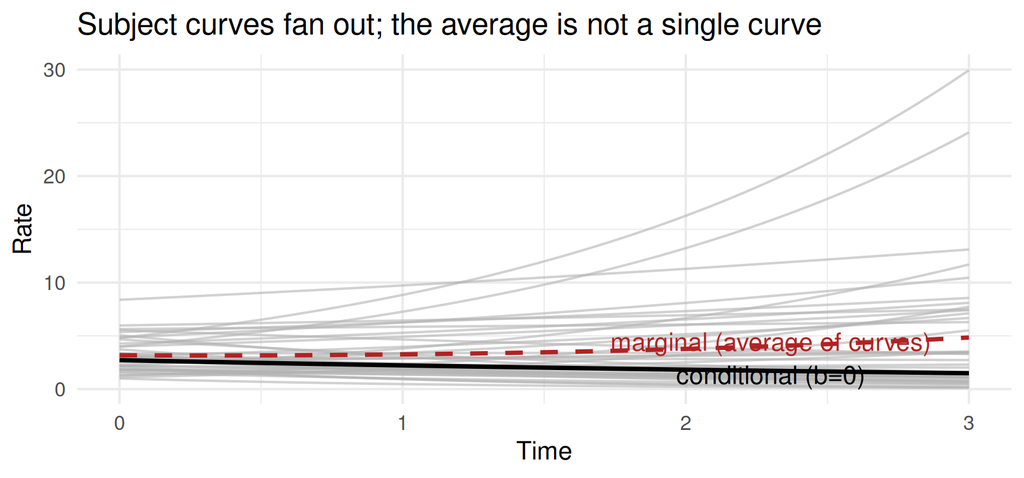

Because subjects **fan out**, the average of the subject curves is not a single curve with the same slope. With a non-linear link, the population-average (marginal) effect is **not** the conditional ($b=0$) effect.

**Note**

**Recall (L14):** the marginal coefficient is an attenuated version of the conditional one. The attenuation gets harder to summarize with a single factor once slopes are random (it varies by covariate level). We quantify the gap on the real fit in Part VII.

## Part IV: Prediction and Empirical Bayes Predictors

## What Are Empirical Bayes Predictors?

**Definition (once, then reused):** the **empirical Bayes (EB) predictor** of subject $i$’s random effects is the posterior mean given that subject’s data,

$$\hat{\mathbf{b}}_i = E[\mathbf{b}_i \mid \mathbf{Y}_i;\, \hat{\boldsymbol\beta}, \hat\phi, \hat G]$$

evaluated at the ML estimates (hence “empirical”). It requires integrating over $\mathbf{b}_i$, so it is computed numerically.

**Note**

FLW use “empirical Bayes” and “empirical BLUP” **interchangeably** for GLMM random-effect predictions (Sec. 14.5, pp. 411-412): $\hat{\mathbf{b}}_i$ “coincides with the empirical Bayes or BLUP used in Chapter 8.” The “linear/unbiased” properties of BLUP are exact only in the LMM; for a GLMM the term is FLW’s convention, not a claim of exact linearity.

## Properties of Empirical Bayes Predictors

| Property | Description |
| --- | --- |
| **Shrinkage** | Extreme observations pulled toward population mean |
| **Reliability** | More shrinkage with fewer observations per subject |
| **Conditioning** | Based on observed data for that subject |
| **Normality leverage** | EB predictors inherit the assumed normal shape (FLW p. 412) |

## Shrinkage Effect (LMM vs GLMM)

**GLMM takeaway:** shrinkage still happens. A subject’s EB predictor is pulled toward the population mean, and **more** so when that subject has few observations or when the between-subject variance is small. We see this directly in the epilepsy shrinkage plot (Part VII).

**Note**

**In the linear (LMM) case this is exact:** the shrinkage factor has a closed form,
$$\frac{\sigma^2_{\text{within}}}{\sigma^2_{\text{within}} + n_i\, \sigma^2_{\text{between}}}.$$
For a GLMM with a non-linear link the same forces operate but there is no simple closed form.

## Computing Empirical Bayes Predictors in R

```r
# After fitting a model:
ranef(model)              # Random effects estimates (EB predictors)
coef(model)               # Fixed + random effects combined
predict(model, type = "response")  # Subject-specific predictions
```

## Subject-Specific Predictions

For subject $i$ at covariate value $x^*$ (with random-effect design row $z^*$):

$$\hat{\mu}_i = g^{-1}\!\left(x^{*}\hat{\boldsymbol\beta} + z^{*}\hat{\mathbf{b}}_i\right)$$

This gives **individual-level predictions** incorporating the subject’s EB-predicted random effects.

# Part II (Day 2, ~75 min): Computation, Selection, Case Study

## Recap of Day 1

On Day 1 we covered specification and interpretation:

- Random slopes let each subject have an individual **rate of change**, with $\mathbf{b}_i \sim N(0, G)$
- $G$ holds $\sigma_0^2$ (intercept var), $\sigma_1^2$ (slope var), $\sigma_{01}$ (their covariance)
- Read variance components through the **inverse link** (exp for log); $\rho_{01}$ is often weak
- $\beta$ is **conditional** on $\mathbf{b}_i$; the marginal effect is attenuated (non-linear link)
- **Empirical Bayes** predictors give shrinkage-based subject-specific estimates

## Part V: Computational Considerations

## The Integration Challenge

**Marginal (integrated) likelihood** (FLW Sec. 14.5):

$$L(\beta, \phi, G) = \prod_{i=1}^N \int \left[\prod_{j=1}^{n_i} f(y_{ij}\mid \mathbf{b}_i; \beta)\right] \phi(\mathbf{b}_i; G)\, d\mathbf{b}_i$$

Unlike the LMM (Ch. 8), this integral has **no closed form** for a non-linear link. With random slopes $\mathbf{b}_i \in \mathbb{R}^q$ (typically $q = 2$), it is a $q$-dimensional integral per subject.

## Adaptive Gauss-Hermite Quadrature (the FLW Ch. 14 method)

**Idea:** approximate the integral by a weighted sum of integrand evaluations.

$$L(\beta,\phi,G) \approx \prod_{i=1}^N \sum_{k=1}^K f(\mathbf{Y}_i \mid \mathbf{b}_i = v_k)\, w_k$$

**Adaptive:** centers the quadrature points $v_k$ near the mode of each subject’s integrand (more accurate than fixed points).

**Note**

This is FLW’s true-likelihood method (Tables 14.2/14.6 used **50-point** adaptive Gaussian quadrature). FLW Table 14.3 shows estimates **stabilize once $K$ exceeds about 30**; using too few points (5-10) gave misleading values. Recommendation: increase $K$ until estimates and SEs stop moving.

## Laplace Approximation (beyond FLW Ch. 14)

**Warning**

**Beyond FLW Ch. 14 (this is FLW Ch. 15 / approximate-methods material).** FLW Ch. 14 names only generic quadrature; it does not derive the Laplace formula and explicitly defers the less-demanding approximate methods (PQL, Laplace-type) to Chapter 15.

**Idea:** approximate the integrand with a single Gaussian centered at the mode.

$$\int f(b)\, db \approx f(\hat{b}) \cdot (2\pi)^{q/2} |H(\hat{b})|^{-1/2}$$

In `lme4`, **`nAGQ = 1` is the Laplace approximation** (one quadrature point at the mode). It is fast and the only option for $q \geq 2$ in `lme4`, but can be biased for sparse/binary data.

## Choosing the Number of Quadrature Points

| nAGQ | Accuracy | When |
| --- | --- | --- |
| 1 (Laplace) | Lowest | Random slopes in `lme4` ($q \geq 2$), large $n_i$ |
| 5-10 | Moderate | Random intercept, small $n_i$ |
| 15-30+ | High | Sparse binary data; raise until stable (FLW Table 14.3) |

**Cost:** time scales as $O(K^q)$, $q$ = number of random effects per subject.

**Note**

**`lme4` limit:** `nAGQ > 1` works only for a **single** random effect ($q=1$). For random slopes ($q \geq 2$) `lme4` uses Laplace; for higher accuracy with $q \geq 2$, use `glmmTMB` or a Bayesian fit.

## Fit Random Intercept Model (Baseline)

```r
# Random intercept Poisson GLMM
fit_ri <- glmer(
  seizures ~ trt * visit + log_base + age_c + (1 | id),
  data = epi_long,
  family = poisson(link = "log")
)

summary(fit_ri)
```

## Fit Random Intercept Model (Baseline)

```
Generalized linear mixed model fit by maximum likelihood (Laplace
  Approximation) [glmerMod]
 Family: poisson  ( log )
Formula: seizures ~ trt * visit + log_base + age_c + (1 | id)
   Data: epi_long

      AIC       BIC    logLik -2*log(L)  df.resid
   1349.1    1373.4    -667.6    1335.1       229

Scaled residuals:
    Min      1Q  Median      3Q     Max
-3.3385 -0.8659 -0.0989  0.5806  7.1501

Random effects:
 Groups Name        Variance Std.Dev.
 id     (Intercept) 0.2702   0.5198
Number of obs: 236, groups:  id, 59

Fixed effects:
                    Estimate Std. Error z value Pr(>|z|)
(Intercept)         0.102483   0.223561   0.458    0.647
trtProgabide       -0.253713   0.179299  -1.415    0.157
visit              -0.041517   0.028680  -1.448    0.148
log_base            1.020695   0.101777  10.029   <2e-16 ***
age_c               0.008282   0.010443   0.793    0.428
trtProgabide:visit -0.031466   0.040345  -0.780    0.435
---
Signif. codes:  0 '***' 0.001 '**' 0.01 '*' 0.05 '.' 0.1 ' ' 1

Correlation of Fixed Effects:
            (Intr) trtPrg visit  log_bs age_c
trtProgabid -0.369
visit       -0.314  0.392
log_base    -0.819 -0.048  0.000
age_c       -0.156  0.016  0.000  0.184
trtPrgbd:vs  0.223 -0.546 -0.711  0.000  0.000
```

## Fit Random Slope Model

```r
# Random intercept + slope for visit
fit_rs <- glmer(
  seizures ~ trt * visit + log_base + age_c + (1 + visit | id),
  data = epi_long,
  family = poisson(link = "log"),
  control = glmerControl(optimizer = "bobyqa", optCtrl = list(maxfun = 1e5))
)

summary(fit_rs)
```

## Fit Random Slope Model

```
Generalized linear mixed model fit by maximum likelihood (Laplace
  Approximation) [glmerMod]
 Family: poisson  ( log )
Formula: seizures ~ trt * visit + log_base + age_c + (1 + visit | id)
   Data: epi_long
Control: glmerControl(optimizer = "bobyqa", optCtrl = list(maxfun = 1e+05))

      AIC       BIC    logLik -2*log(L)  df.resid
   1333.8    1365.0    -657.9    1315.8       227

Scaled residuals:
    Min      1Q  Median      3Q     Max
-2.9935 -0.7827 -0.0961  0.5458  6.3786

Random effects:
 Groups Name        Variance Std.Dev. Corr
 id     (Intercept) 0.42239  0.6499
        visit       0.02133  0.1461   -0.61
Number of obs: 236, groups:  id, 59

Fixed effects:
                    Estimate Std. Error z value Pr(>|z|)
(Intercept)         0.091225   0.238537   0.382    0.702
trtProgabide       -0.300367   0.218408  -1.375    0.169
visit              -0.043466   0.044081  -0.986    0.324
log_base            1.020904   0.101389  10.069   <2e-16 ***
age_c               0.007992   0.010419   0.767    0.443
trtProgabide:visit -0.010119   0.062746  -0.161    0.872
---
Signif. codes:  0 '***' 0.001 '**' 0.01 '*' 0.05 '.' 0.1 ' ' 1

Correlation of Fixed Effects:
            (Intr) trtPrg visit  log_bs age_c
trtProgabid -0.423
visit       -0.462  0.496
log_base    -0.759 -0.039 -0.015
age_c       -0.142  0.016 -0.009  0.184
trtPrgbd:vs  0.318 -0.729 -0.673  0.000 -0.005
```

## Understanding `VarCorr()` Output

```r
vc <- VarCorr(fit_rs)
print(vc)                 # human-readable: SDs on the diagonal, Corr off-diagonal
```

**Note**

`VarCorr(fit)` returns a **list keyed by grouping factor**, so `VarCorr(fit)$id` is the $2\times2$ covariance $\hat G$ for the `id` grouping. `print()` shows **standard deviations** (not variances) and the correlation. `as.data.frame(vc)$sdcor` is ordered: intercept SD, slope SD, then the correlation.

## Understanding `VarCorr()` Output

```
 Groups Name        Std.Dev. Corr
 id     (Intercept) 0.64991
        visit       0.14606  -0.607
```

## Interpret the Random Effects Structure

```r
vc_df <- as.data.frame(vc)
sigma_int   <- vc_df$sdcor[1]   # intercept SD
sigma_slope <- vc_df$sdcor[2]   # slope SD
rho         <- vc_df$sdcor[3]   # intercept-slope correlation

cat("Random intercept SD:", round(sigma_int, 3), "\n")
```

## Interpret the Random Effects Structure

```
Random intercept SD: 0.65
```

```r
cat("Random slope SD:    ", round(sigma_slope, 3), "\n")
```

```
Random slope SD:     0.146
```

```r
cat("Intercept-slope correlation:", round(rho, 3), "\n")
```

```
Intercept-slope correlation: -0.607
```

## Check Your Understanding: Variance Components

**Question:** A Poisson GLMM for hospital readmission counts yields:

- Random intercept SD: $\sigma_0 = 0.8$
- Random slope SD (for time): $\sigma_1 = 0.3$
- Intercept-slope correlation: $\rho_{01} = -0.6$

**Interpret these results clinically.**

**Answer:**

1. **$\sigma_0 = 0.8$**: Substantial between-patient variability in baseline readmission rates. On the log scale, patients vary by roughly $\pm 1.6$ (i.e., $\pm 2 \times 0.8$), meaning some patients have baseline rates $\exp(1.6) \approx 5$ times higher than others.
2. **$\sigma_1 = 0.3$**: Patients differ in how their readmission risk changes over time. Some improve faster, others slower.
3. **$\rho_{01} = -0.6$**: Patients with higher baseline readmission rates tend to show more improvement (steeper decline) over time. This could reflect regression to the mean or that high-risk patients benefit more from interventions.

## Increase Quadrature Points for Accuracy

```r
# Fit with adaptive Gauss-Hermite (nAGQ > 1)
# Note: nAGQ > 1 only works with 1 random effect dimension in lme4
# For 2+ random effects, use glmmTMB or stay with Laplace

fit_ri_agq <- glmer(
  seizures ~ trt * visit + log_base + age_c + (1 | id),
  data = epi_long,
  family = poisson(link = "log"),
  nAGQ = 10
)

# Compare coefficient estimates
cbind(Laplace = fixef(fit_ri), AGQ10 = fixef(fit_ri_agq)) %>% round(4)
```

## Increase Quadrature Points for Accuracy

```
                   Laplace   AGQ10
(Intercept)         0.1025  0.1023
trtProgabide       -0.2537 -0.2539
visit              -0.0415 -0.0415
log_base            1.0207  1.0207
age_c               0.0083  0.0083
trtProgabide:visit -0.0315 -0.0315
```

## A Word on PQL and MQL (FLW Ch. 15)

**Note**

**Penalized quasi-likelihood (PQL)** and **marginal quasi-likelihood (MQL)** are *approximate* estimation methods (a Laplace/Taylor-expansion approach), the subject of FLW **Chapter 15**, not Chapter 14.

- **PQL** (`MASS::glmmPQL`) is fast and the only “legitimate” approximate method of the two, but **biased**, worst for **binary** outcomes and **few-cluster** data.
- **MQL** does **not** even estimate the GLMM parameters and is generally not recommended.
- **Benchmark:** adaptive Gaussian quadrature (the Ch. 14 method we use) is the **more accurate** integrated-likelihood estimator. Prefer it when feasible; reach for PQL only when AGQ is computationally out of reach.

## Software for Flexible GLMMs

For more complex models (negative binomial, zero-inflation), consider:

| Package | Features |
| --- | --- |
| `lme4::glmer` | ML via Laplace / AGQ (used here); Poisson, binomial |
| `glmmTMB` | Negative binomial, zero-inflation, flexible covariance |
| `brms` | Bayesian GLMMs with Stan (full posterior) |
| `MCMCglmm` | Bayesian with multivariate response |
| `MASS::glmmPQL` | Penalized quasi-likelihood (PQL); fast, approximate, biased (FLW Ch. 15) |

## Part VI: Model Selection and Comparison

## Model Comparison Approaches

| Method | Use Case | Notes |
| --- | --- | --- |
| **LRT** | Nested models | Chi-square approximation may fail at boundary |
| **AIC/BIC** | Non-nested OK | BIC more conservative |
| **Profile CI** | Single parameters | More accurate than Wald |

## Likelihood Ratio Test: Random Slope

```r
# Compare random intercept vs random intercept + slope
# (this drops TWO parameters: the slope variance AND the intercept-slope covariance)
anova(fit_ri, fit_rs)
```

## Likelihood Ratio Test: Random Slope

```
Data: epi_long
Models:
fit_ri: seizures ~ trt * visit + log_base + age_c + (1 | id)
fit_rs: seizures ~ trt * visit + log_base + age_c + (1 + visit | id)
       npar    AIC    BIC  logLik -2*log(L) Chisq Df Pr(>Chisq)
fit_ri    7 1349.1 1373.4 -667.56    1335.1
fit_rs    9 1333.8 1365.0 -657.92    1315.8 19.28  2  6.506e-05 ***
---
Signif. codes:  0 '***' 0.001 '**' 0.01 '*' 0.05 '.' 0.1 ' ' 1
```

## LRT Caveat: Boundary Mixture (Stram-Lee)

Testing whether to add the random slope puts the null **on the boundary** of the parameter space, so the reference distribution is **not** a plain $\chi^2$.

**Warning**

**This test drops TWO parameters** ($\sigma_1^2$ **and** $\sigma_{01}$), so the correct reference is the **Stram-Lee 50:50 mixture**
$$\tfrac12\chi^2_1 + \tfrac12\chi^2_2,$$
**NOT** “halve the p-value” (which is right only for a single 1-df boundary test). Dropping just a 1-df variance would use $\tfrac12\chi^2_0 + \tfrac12\chi^2_1$; dropping a slope from a random-intercept model is the 1-vs-2 case above.

```r
# anova() reports a naive 2-df chi-square; recompute under the Stram-Lee mixture
lrt <- anova(fit_ri, fit_rs)
G2  <- lrt$Chisq[2]
p_naive   <- lrt$`Pr(>Chisq)`[2]                            # naive chi^2_2
p_mixture <- 0.5 * pchisq(G2, 1, lower.tail = FALSE) +
             0.5 * pchisq(G2, 2, lower.tail = FALSE)          # 1/2 chi^2_1 + 1/2 chi^2_2
cat("LRT statistic G^2:", round(G2, 2), "\n")
```

**Note**

**Gold standard for a GLMM:** the exact-LRT simulation in `RLRsim` is **Gaussian-LMM only**. For this **Poisson** GLMM use a **parametric bootstrap** instead (`pbkrtest::PBmodcomp(fit_rs, fit_ri)`), which simulates the null reference distribution directly and needs no boundary formula.

## LRT Caveat: Boundary Mixture (Stram-Lee)

```
LRT statistic G^2: 19.28
```

```r
cat("Naive 2-df p-value:        ", signif(p_naive, 3), "\n")
```

```
Naive 2-df p-value:         6.51e-05
```

```r
cat("Stram-Lee mixture p-value: ", signif(p_mixture, 3), "\n")
```

```
Stram-Lee mixture p-value:  3.82e-05
```

## AIC/BIC Comparison

```r
model_comparison <- data.frame(
  Model = c("Random Intercept (Poisson)", "Random Slope (Poisson)"),
  AIC = c(AIC(fit_ri), AIC(fit_rs)),
  BIC = c(BIC(fit_ri), BIC(fit_rs))
)
model_comparison
```

## AIC/BIC Comparison

```
                       Model      AIC      BIC
1 Random Intercept (Poisson) 1349.117 1373.364
2     Random Slope (Poisson) 1333.837 1365.012
```

## Check Overdispersion in Poisson Model

```r
# Check overdispersion in Poisson model
pearson_resid <- residuals(fit_rs, type = "pearson")
overdispersion <- sum(pearson_resid^2) / df.residual(fit_rs)
cat("Overdispersion ratio (Poisson):", round(overdispersion, 2), "\n")
```

## Check Overdispersion in Poisson Model

```
Overdispersion ratio (Poisson): 1.28
```

## When to Choose Negative Binomial

| Overdispersion Ratio | Recommendation |
| --- | --- |
| < 1.5 | Poisson adequate |
| 1.5 - 2.5 | Consider NB |
| > 2.5 | Strongly prefer NB |

Random effects can absorb **some** overdispersion, but not all.

## Likelihood (MAR) vs GEE (MCAR)

A signature GLMM advantage (FLW Sec. 14.5; Table 14.4 footnote, p. 420):

**Note**

Likelihood-based GLMM estimation (what `glmer` does) gives **valid inference under MAR** (missing at random), provided the model is correctly specified. **GEE / marginal models require the stronger MCAR** (missing completely at random).

- Epilepsy and most longitudinal trials have **dropout**, so this matters in practice.
- It is a reason to prefer the likelihood-based mixed model when the scientific target is subject-specific and data are incomplete.

## Part VII: Applied Case Study - Complete Analysis

## Final Model: Poisson with Random Slopes

```r
# Refit with centered visit for interpretability
epi_long <- epi_long %>%
  mutate(visit_c = visit - mean(visit))

final_model <- glmer(
  seizures ~ trt * visit_c + log_base + age_c + (1 + visit_c | id),
  data = epi_long,
  family = poisson(link = "log"),
  control = glmerControl(optimizer = "bobyqa", optCtrl = list(maxfun = 1e5))
)

broom.mixed::tidy(final_model, effects = "fixed", conf.int = TRUE)
```

## Final Model: Poisson with Random Slopes

```
# A tibble: 6 × 8
  effect term           estimate std.error statistic  p.value conf.low conf.high
  <chr>  <chr>             <dbl>     <dbl>     <dbl>    <dbl>    <dbl>     <dbl>
1 fixed  (Intercept)    -0.0174     0.212    -0.0824 9.34e- 1  -0.432     0.397
2 fixed  trtProgabide   -0.326      0.150    -2.18   2.95e- 2  -0.619    -0.0324
3 fixed  visit_c        -0.0435     0.0441   -0.986  3.24e- 1  -0.130     0.0429
4 fixed  log_base        1.02       0.101    10.1    7.56e-24   0.822     1.22
5 fixed  age_c           0.00799    0.0104    0.767  4.43e- 1  -0.0124    0.0284
6 fixed  trtProgabide:… -0.0101     0.0627   -0.161  8.72e- 1  -0.133     0.113
```

## Fixed Effects Interpretation

```r
# Exponentiate for rate ratios
fe <- broom.mixed::tidy(final_model, effects = "fixed", conf.int = TRUE) %>%
  mutate(
    RR = exp(estimate),
    RR_lower = exp(conf.low),
    RR_upper = exp(conf.high)
  ) %>%
  dplyr::select(term, estimate, RR, RR_lower, RR_upper, p.value)

fe
```

## Fixed Effects Interpretation

```
# A tibble: 6 × 6
  term                 estimate    RR RR_lower RR_upper  p.value
  <chr>                   <dbl> <dbl>    <dbl>    <dbl>    <dbl>
1 (Intercept)          -0.0174  0.983    0.649    1.49  9.34e- 1
2 trtProgabide         -0.326   0.722    0.539    0.968 2.95e- 2
3 visit_c              -0.0435  0.957    0.878    1.04  3.24e- 1
4 log_base              1.02    2.78     2.28     3.39  7.56e-24
5 age_c                 0.00799 1.01     0.988    1.03  4.43e- 1
6 trtProgabide:visit_c -0.0101  0.990    0.875    1.12  8.72e- 1
```

## Rate Ratio Interpretation

| Effect | Interpretation |
| --- | --- |
| trtProgabide | Treatment effect at average visit |
| visit_c | Time trend for placebo group |
| log_base | Per-unit increase in log baseline rate |
| trt:visit_c | Differential time trend for progabide vs placebo |

All effects are **conditional** on random effects (subject-specific).

## Reproducing FLW’s Exact Ch. 14 Model

FLW’s actual model uses an **offset** $\log(T_{ij})$ (8 wk baseline, 2 wk follow-up), the **baseline period included** ($j=0$), and a **binary** Time indicator:

$$\log E(Y_{ij}\mid \mathbf{b}_i) = \log(T_{ij}) + (\beta_1 + b_{1i}) + (\beta_2 + b_{2i})\,\text{Time}_{ij} + \beta_3 \text{Trt}_i + \beta_4 \text{Trt}_i\!\times\!\text{Time}_{ij}$$

```r
# Rebuild in FLW's layout: baseline as period 0, offset for time-at-risk, binary Time
flw <- epi_raw %>%
  pivot_longer(cols = c(base, y1, y2, y3, y4),
               names_to = "period", values_to = "count") %>%
  mutate(
    Time = ifelse(period == "base", 0, 1),          # binary baseline/follow-up
    Tij  = ifelse(period == "base", 8, 2),           # weeks at risk
    Trt  = factor(trt, levels = c(0, 1), labels = c("Placebo", "Progabide"))
  )

flw_fit <- glmer(count ~ Time * Trt + (1 + Time | id),
  data = flw, family = poisson(link = "log"), offset = log(Tij),
  control = glmerControl(optimizer = "bobyqa", optCtrl = list(maxfun = 1e5)))

round(fixef(flw_fit), 4)        # compare to FLW Table 14.6
```

**Note**

This matches **FLW Table 14.6** closely: Intercept $\approx 1.07$, Time $\approx 0.00$, Trt $\approx 0.05$, Trt$\times$Time $\approx -0.31$ (FLW: 1.0707, -0.0004, 0.0513, -0.3065). The intercept-slope correlation is again near zero ($g_{12}=0.054$, LRT $p>0.95$).

## Reproducing FLW’s Exact Ch. 14 Model

```
      (Intercept)              Time      TrtProgabide Time:TrtProgabide
           1.0709           -0.0005            0.0512           -0.3062
```

```r
print(VarCorr(flw_fit))
```

```
 Groups Name        Std.Dev. Corr
 id     (Intercept) 0.70701
        Time        0.48161  0.160
```

## Outlier and Overdispersion: FLW’s Resolution

```r
# (1) Refit excluding patient 49 (the 151/302-count outlier; FLW Table 14.7)
flw_fit49 <- glmer(count ~ Time * Trt + (1 + Time | id),
  data = subset(flw, id != 49), family = poisson(link = "log"),
  offset = log(Tij),
  control = glmerControl(optimizer = "bobyqa", optCtrl = list(maxfun = 1e5)))

# (2) Negative binomial mixed model, excluding 49 (FLW Table 14.8); needs glmmTMB
nb_fit <- glmmTMB::glmmTMB(count ~ Time * Trt + (1 + Time || id),
  data = subset(flw, id != 49), family = glmmTMB::nbinom2,
  offset = log(Tij))

rbind(
  `Poisson, full (T14.6)`      = fixef(flw_fit),
  `Poisson, excl 49 (T14.7)`   = fixef(flw_fit49),
  `Neg. binom, excl 49 (T14.8)`= glmmTMB::fixef(nb_fit)$cond
) |> round(4)
```

**Note**

Patient 49 (151 baseline, 302 follow-up seizures) inflates the variance components. Excluding it (Table 14.7) and switching to a **negative binomial** mixed model (Table 14.8) is FLW’s actual overdispersion remedy. The Trt$\times$Time effect is stable across all three (about $-0.31$ to $-0.36$), so the treatment conclusion is robust.

## Outlier and Overdispersion: FLW’s Resolution

```
                            (Intercept)    Time TrtProgabide Time:TrtProgabide
Poisson, full (T14.6)            1.0709 -0.0005       0.0512           -0.3062
Poisson, excl 49 (T14.7)         1.0694  0.0078      -0.0080           -0.3459
Neg. binom, excl 49 (T14.8)      1.0988  0.0056       0.0034           -0.3584
```

## Extract and Visualize Empirical Bayes Predictors

```r
# Get random effects
re <- ranef(final_model)$id
colnames(re) <- c("Intercept", "Slope")
re$id <- rownames(re)

ggplot(re, aes(x = Intercept, y = Slope)) +
  geom_point(alpha = 0.7, size = 2) +
  geom_hline(yintercept = 0, linetype = "dashed", color = "red") +
  geom_vline(xintercept = 0, linetype = "dashed", color = "red") +
  labs(x = "Random Intercept (log scale)",
       y = "Random Slope for Visit",
       title = "Subject-Specific Deviations from Population Mean") +
  annotate("text", x = max(re$Intercept) * 0.8, y = min(re$Slope) * 0.8,
           label = paste("Correlation:", round(cor(re$Intercept, re$Slope), 2)))
```

## Extract and Visualize Empirical Bayes Predictors

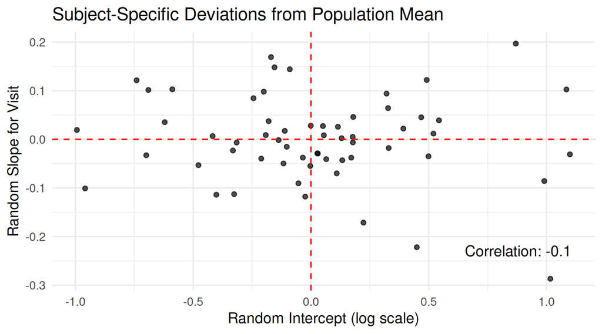

## Subject-Specific Predictions

```r
# Predictions for each subject
epi_long$pred <- predict(final_model, type = "response")

# Plot for 9 random subjects
set.seed(42)
sample_ids <- sample(unique(epi_long$id), 9)

epi_long %>%
  filter(id %in% sample_ids) %>%
  ggplot(aes(x = visit)) +
  geom_point(aes(y = seizures), alpha = 0.7) +
  geom_line(aes(y = pred), color = "blue", linewidth = 1) +
  facet_wrap(~id, scales = "free_y", ncol = 3) +
  labs(x = "Visit", y = "Seizure Count",
       title = "Observed (points) vs Subject-Specific Predictions (lines)")
```

## Subject-Specific Predictions

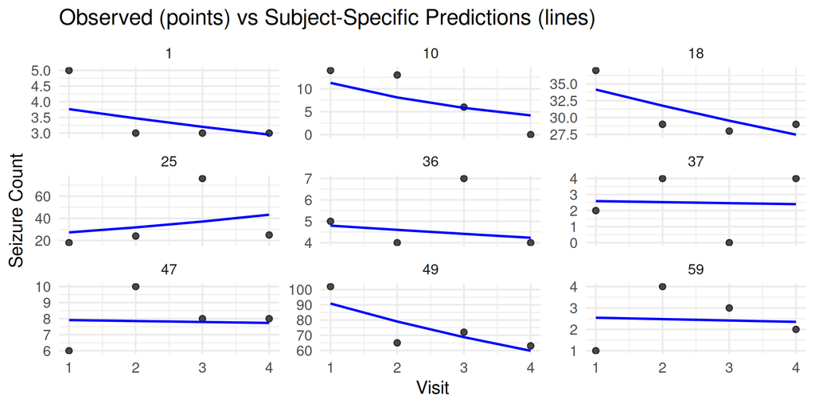

## Empirical Bayes Shrinkage Illustration

```r
# Compare observed means to predicted (shrunk) means
subject_summary <- epi_long %>%
  group_by(id, trt) %>%
  summarise(
    observed_mean = mean(seizures),
    predicted_mean = mean(pred),
    n_obs = n(),
    .groups = "drop"
  )

ggplot(subject_summary, aes(x = observed_mean, y = predicted_mean, color = trt)) +
  geom_point(alpha = 0.7, size = 2) +
  geom_abline(slope = 1, intercept = 0, linetype = "dashed") +
  labs(x = "Observed Mean Seizures", y = "Predicted Mean (Shrunk)",
       title = "Empirical Bayes Shrinkage: Predictions vs Observed",
       subtitle = "Points below diagonal show shrinkage toward population mean") +
  coord_equal()
```

**Note**

**Reading it:** the dashed line is “no shrinkage” (predicted = observed). Points pulled **toward the population mean** (off the line, especially extreme subjects with few/noisy observations) show empirical Bayes shrinkage in action.

## Empirical Bayes Shrinkage Illustration

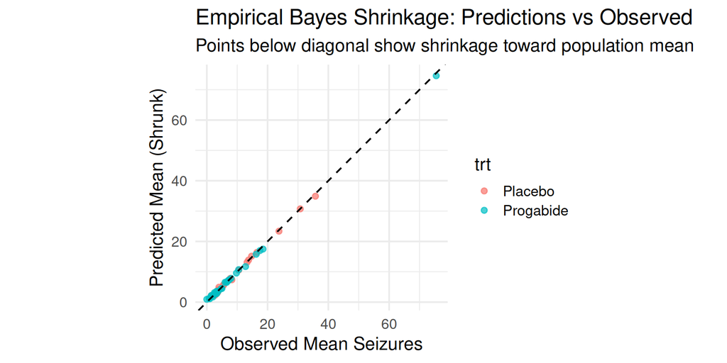

## Diagnostic: Residuals vs Fitted, Residuals by Visit

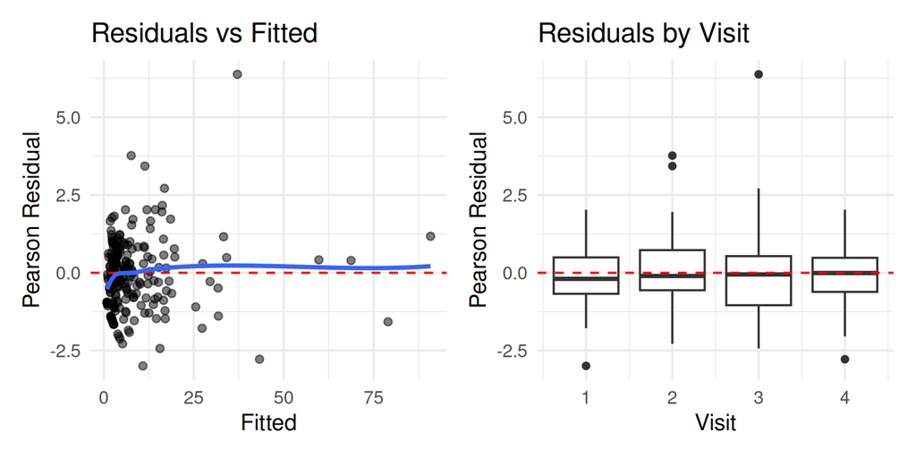

**Note**

**Reading it.** Left (residuals vs fitted): the red line at 0 is the target; a flat blue smoother and a roughly symmetric, constant-width band is good. A funnel (spread growing with the fitted value) signals **overdispersion**, expected here and the reason we consider negative binomial. Right (residuals by visit): each box should center on 0 with similar spread; a drifting median means the **time trend is mis-specified**.

## Diagnostic: Random Effects Q-Q Plots

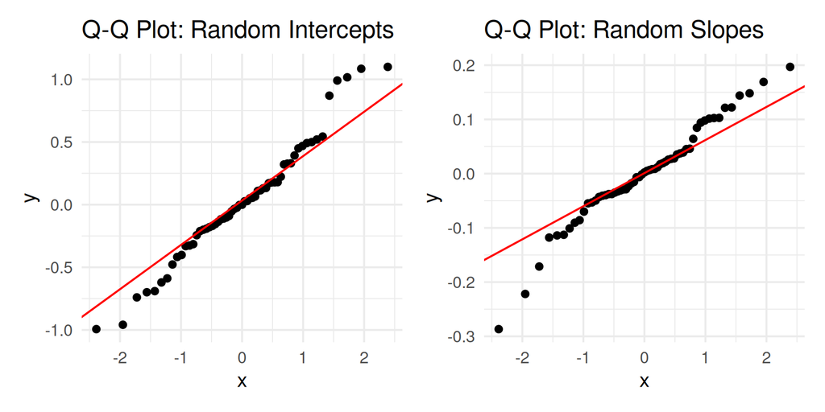

**Note**

**Reading it.** Points on the red line support normality of the random effects. **Points curving up at the right** are a heavy right tail (positive skew); points curving down at the left are a heavy left tail. A few extreme points at the very ends are usually fine.

**Warning**

**Caveat (FLW p. 412):** empirical BLUPs are shrunk toward a normal, so a clean Q-Q plot does **not** by itself confirm normality. Fixed-effect estimates are fairly robust to non-normal random effects; treat these plots as a rough screen, not a formal test.

## Q-Q Plot Pattern Reference

**Quick reference for random-effects Q-Q patterns:**

| Pattern | Interpretation | Concern |
| --- | --- | --- |
| Points on the line | Normality satisfied | None |
| Slight S-curve | Light tails | Minor |
| Curving up at right | Heavy right tail (positive skew) | Moderate |
| Curving down at left | Heavy left tail (negative skew) | Moderate |
| Systematic departure | Severe non-normality | Serious |

## Identifying Influential Subjects

```r
# Subjects with extreme random effects
extreme_subjects <- re %>%
  mutate(
    extreme_int = abs(Intercept) > 2 * sd(Intercept),
    extreme_slope = abs(Slope) > 2 * sd(Slope)
  ) %>%
  filter(extreme_int | extreme_slope)

cat("Subjects with extreme random effects:\n")
```

## Identifying Influential Subjects

```
Subjects with extreme random effects:
```

```r
print(extreme_subjects)
```

```
    Intercept       Slope id extreme_int extreme_slope
8   0.4494711 -0.22187529  8       FALSE          TRUE
10  1.0164095 -0.28675332 10        TRUE          TRUE
16 -0.9587330 -0.10099345 16        TRUE         FALSE
25  0.8700290  0.19686056 25       FALSE          TRUE
35  1.0996060 -0.03093807 35        TRUE         FALSE
49  0.9906770 -0.08582488 49        TRUE         FALSE
56  1.0846777  0.10252224 56        TRUE         FALSE
58 -0.9936508  0.01924798 58        TRUE         FALSE
```

## Predictions at $b_i = 0$ (re.form = NA): the Concept

**Critical distinction:** `re.form = NA` gives predictions at $\mathbf{b}_i = 0$, which is **NOT** the true marginal (population-average) prediction.

Per FLW (p. 477): for non-linear links, $E[Y \mid \mathbf{b} = 0] \neq E[Y]$.

- `re.form = NA`: a hypothetical subject with $\mathbf{b}_i = 0$ (the “typical” subject)
- True marginal: $E[Y] = \displaystyle\int g^{-1}(X_{ij}\beta + Z_{ij}\mathbf{b})\, \phi(\mathbf{b}; G)\, d\mathbf{b}$

**Warning**

Reporting `re.form = NA` as a population-average mean is a common error. For a log link the true marginal is **larger** (Jensen). We quantify the gap two slides on.

## Predictions at $b_i = 0$: the Code

```r
# Create prediction grid
newdata <- expand.grid(
  trt = c("Placebo", "Progabide"),
  visit_c = seq(-1.5, 1.5, length.out = 50),
  log_base = mean(epi_long$log_base),
  age_c = 0
)

# Predictions at b_i = 0 (NOT marginal/population-average!)
newdata$pred <- predict(final_model, newdata = newdata,
                        re.form = NA, type = "response")

ggplot(newdata, aes(x = visit_c + 2.5, y = pred, color = trt)) +
  geom_line(linewidth = 1.2) +
  labs(x = "Visit", y = "Predicted Seizure Rate",
       title = "Predictions at b = 0 (Conditional on Zero Random Effects)",
       subtitle = "Note: This is NOT the same as true marginal/population-average predictions",
       color = "Treatment")
```

## Predictions at $b_i = 0$: the Code

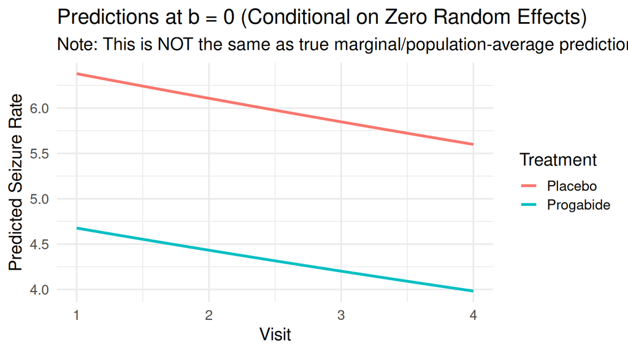

## True Marginal Predictions Require Integration

For GLMMs with non-linear links, the true marginal mean is

$$E[Y_{ij}] = \int g^{-1}(X_{ij}\beta + Z_{ij}\mathbf{b})\, \phi(\mathbf{b}; G)\, d\mathbf{b}$$

**Ways to evaluate it:**

1. **Monte Carlo integration:** simulate many $\mathbf{b}$ from $N(0, G)$, predict, average (we use this)
2. **Numerical quadrature:** Gauss-Hermite approximation of the integral

**Note**

A closed-form **attenuation factor** (Zeger-Liang) exists for some links but is a Ch. 16 / Zeger, Liang & Albert (1988) result, **beyond FLW Ch. 14**. Monte Carlo is exact up to simulation error and needs no such formula.

## Monte Carlo Marginal Predictions: the Recipe

The marginal mean is $E[Y] = \int g^{-1}(X_{ij}\beta + Z_{ij}\mathbf{b})\,\phi(\mathbf{b};G)\,d\mathbf{b}$. Approximate it:

```
1. Simulate b_1, ..., b_M  ~  N(0, G_hat)         # M = 2000 draws from the fitted G
2. For each prediction point:
     eta_fixed = X*beta_hat                         # linear predictor at b = 0 (re.form = NA)
     for each draw b_m:  eta_m = eta_fixed + z' b_m  # add the random part, z = (1, visit_c)
3. Average exp(eta_m) over the M draws              # inverse link (exp) then Monte Carlo mean
```

**Note**

**Assumptions:** a **single** grouping factor and a **Poisson/log** link ($g^{-1} = \exp$). For other families swap the inverse link in step 3; for crossed/nested grouping factors the simulation is more involved.

## Monte Carlo Marginal Predictions: the Function

```r
# Monte Carlo approach for true marginal predictions with random slopes
compute_marginal_poisson <- function(fit, newdata, n_sim = 2000, seed = 667) {
  set.seed(seed)

  # --- Step 1: draw b ~ N(0, G_hat) ------------------------------------------
  # VarCorr(fit) is a LIST keyed by grouping factor; $id is the 2x2 G_hat
  # (assumes a SINGLE grouping factor named "id")
  G_hat <- as.matrix(VarCorr(fit)$id)
  b_sim <- MASS::mvrnorm(n_sim, mu = c(0, 0), Sigma = G_hat)   # n_sim x 2

  # Fixed-effect linear predictor at b = 0 (the X*beta term), one per grid point
  eta_fixed <- predict(fit, newdata = newdata, re.form = NA, type = "link")

  # --- Step 2 & 3: add z'b per draw, inverse-link, then average --------------
  marginal_preds <- sapply(seq_along(eta_fixed), function(i) {
    z_i <- c(1, newdata$visit_c[i])     # random-effects design row z = (intercept, slope)
    eta_with_re <- eta_fixed[i] + b_sim %*% z_i   # Step 2: X*beta + z'b for all draws
    mean(exp(eta_with_re))              # Step 3: exp() is g^{-1}; mean() is the MC integral
  })

  return(marginal_preds)
}

# Apply to prediction grid
newdata_marginal <- expand.grid(
  trt = c("Placebo", "Progabide"),
  visit_c = c(-1.5, 0, 1.5),
  log_base = mean(epi_long$log_base),
  age_c = 0
)

newdata_marginal$pred_b0 <- predict(final_model, newdata = newdata_marginal,
                                     re.form = NA, type = "response")
newdata_marginal$pred_marginal <- compute_marginal_poisson(final_model, newdata_marginal)

# Compare predictions
contrast_tbl <- newdata_marginal %>%
  mutate(visit = visit_c + 2.5,
         difference = pred_marginal - pred_b0,
         pct_diff = round(100 * difference / pred_b0, 1)) %>%
  dplyr::select(trt, visit, pred_b0, pred_marginal, pct_diff)
contrast_tbl
```

## Monte Carlo Marginal Predictions: the Function

```
        trt visit  pred_b0 pred_marginal pct_diff
1   Placebo   1.0 6.379507      7.484249     17.3
2 Progabide   1.0 4.676739      5.486612     17.3
3   Placebo   2.5 5.976849      6.825309     14.2
4 Progabide   2.5 4.315537      4.928161     14.2
5   Placebo   4.0 5.599607      6.517867     16.4
6 Progabide   4.0 3.982233      4.635265     16.4
```

## Conditional vs Marginal: the Number

For the epilepsy fit, the true marginal (population-average) seizure rate is about **16% higher** than the conditional ($b=0$) prediction. For the placebo group at the average visit: conditional rate **5.98**, marginal rate **6.83** (a **14.2%** gap).

**Note**

This is FLW’s Ch. 14 signature point (Table 14.1 illustration: the population-average effect is roughly **15-25% smaller/larger** than the subject-specific one). Here the gap is driven by the **random-intercept variance** through Jensen ($E[\exp(\cdot)] > \exp(E[\cdot])$). The treatment **rate ratio** is nearly unchanged, because a shared-scale random intercept multiplies both arms equally; the gap shows up in the **level**, not the ratio.

## Interpreting the Marginal vs b=0 Difference

```r
# Visualize the difference
newdata_plot <- expand.grid(
  trt = c("Placebo", "Progabide"),
  visit_c = seq(-1.5, 1.5, length.out = 20),
  log_base = mean(epi_long$log_base),
  age_c = 0
)

newdata_plot$pred_b0 <- predict(final_model, newdata = newdata_plot,
                                 re.form = NA, type = "response")
newdata_plot$pred_marginal <- compute_marginal_poisson(final_model, newdata_plot)

newdata_plot %>%
  pivot_longer(cols = c(pred_b0, pred_marginal),
               names_to = "type", values_to = "pred") %>%
  mutate(type = recode(type,
                       pred_b0 = "At b=0 (re.form=NA)",
                       pred_marginal = "True Marginal (MC)"),
         visit = visit_c + 2.5) %>%
  ggplot(aes(x = visit, y = pred, color = trt, linetype = type)) +
  geom_line(linewidth = 1) +
  labs(x = "Visit", y = "Predicted Seizure Rate",
       title = "True Marginal vs b=0 Predictions",
       subtitle = "True marginal predictions are higher due to Jensen's inequality (log link)",
       color = "Treatment", linetype = "Prediction Type") +
  theme(legend.position = "bottom")
```

**Key insight:** For log link, true marginal > b=0 prediction because $E[\exp(X)] > \exp(E[X])$ (Jensen).

## Interpreting the Marginal vs b=0 Difference

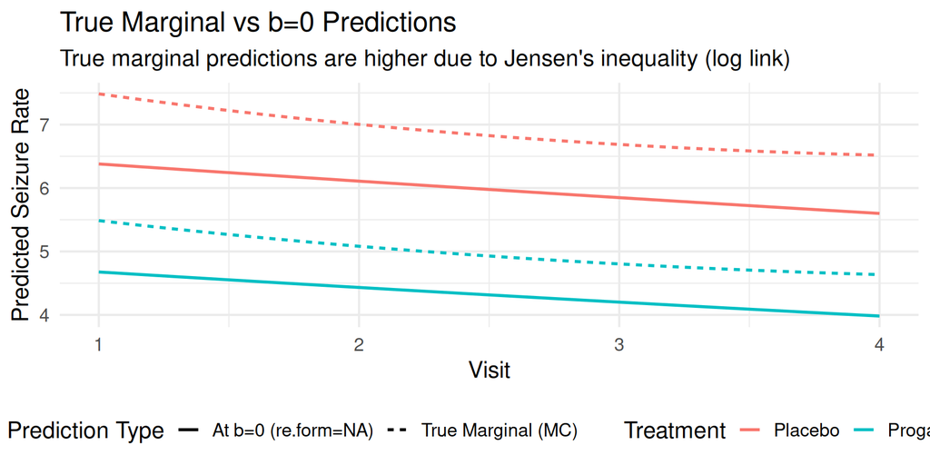

## Uncorrelated Random Effects (Alternative)

```r
# Sometimes useful when correlation is near-zero or causing convergence issues
fit_uncorr <- glmer(
  seizures ~ trt * visit_c + log_base + age_c +
    (1 | id) + (0 + visit_c | id),  # Uncorrelated
  data = epi_long,
  family = poisson(link = "log"),
  control = glmerControl(optimizer = "bobyqa", optCtrl = list(maxfun = 1e5))
)

# Compare AIC
cat("Correlated RE AIC:", round(AIC(final_model), 1), "\n")
```

## Uncorrelated Random Effects (Alternative)

```
Correlated RE AIC: 1333.8
```

```r
cat("Uncorrelated RE AIC:", round(AIC(fit_uncorr), 1), "\n")
```

```
Uncorrelated RE AIC: 1331.9
```

## Why Use Uncorrelated Random Effects?

| Situation | Recommendation |
| --- | --- |
| Correlation near 0 | Uncorrelated may be sufficient |
| Convergence issues | Uncorrelated often more stable |
| Few observations per subject | Correlation hard to estimate |
| Scientific interest in correlation | Keep correlated structure |

## Understanding the Uncorrelated Syntax

**Syntax:** `(1 | id) + (0 + visit_c | id)`

Let us break this down:

- `(1 | id)` - random intercept for each subject
- `(0 + visit_c | id)` - random slope for `visit_c`, **without** an intercept in this term

**Why `0 +`?** The `0 +` removes the implicit intercept from the second random effects term. Without it, `(visit_c | id)` would estimate both an intercept AND a slope, leading to redundancy.

**The key insight:** When you specify two separate random effects terms for the same grouping factor, `lme4` estimates them **independently** (i.e., assumes zero correlation).

**Comparison:**

- `(1 + visit_c | id)` - estimates $\sigma_0^2$, $\sigma_1^2$, and $\rho_{01}$ (3 parameters)
- `(1 | id) + (0 + visit_c | id)` - estimates $\sigma_0^2$ and $\sigma_1^2$ only (2 parameters, $\rho_{01} = 0$)

## Convergence Troubleshooting Summary

| Issue | Solution |
| --- | --- |
| Model fails to converge | Center continuous predictors |
| Singular fit (variance = 0) | Drop the problematic random effect |
| Near-singular Hessian | Simplify random effects structure |
| Very slow fitting | Reduce nAGQ or use Laplace |

## SAS Equivalent (reference only)

FLW Tables 14.2/14.6 use `PROC GLIMMIX` with adaptive quadrature. The standalone program for our random-slope Poisson GLMM:

```sas
proc glimmix data=epilepsy method=quad(qpoints=50);
  class id;
  model seizures = trt|visit_c log_base age_c
        / dist=poisson link=log solution;
  random intercept visit_c / subject=id type=un;
run;
```

**Note**

`trt|visit_c` expands to the main effects and their interaction. `type=un` gives the **unstructured** $2\times2$ $G$ (the correlated form); use `type=vc` for the uncorrelated version. `method=quad(qpoints=50)` requests 50-point adaptive Gaussian quadrature, matching FLW; `/solution` prints the fixed-effect estimates.

## Practical Workflow for Random Slope GLMMs

1. Start with the **random intercept** model
2. Add **random slopes** one at a time
3. Check **convergence** and variance estimates (watch for singular fits)
4. Justify complexity with **LRT (boundary mixture) or AIC**
5. Check **overdispersion** (counts); consider negative binomial
6. Examine **empirical Bayes** predictor distributions
7. Run **diagnostics** on residuals and random effects
8. Report **both conditional and marginal** effects

## Summary

- Random slopes allow **subject-specific covariate effects**
- The correlation $\rho_{01}$ between intercepts and slopes is often interpretable
- Empirical Bayes predictors provide shrinkage-based predictions for individual subjects
- `re.form = NA` gives predictions at $b_i = 0$, **not** true marginal predictions
- Computation is harder: Laplace for speed, AGQ for accuracy
- Model selection balances fit (AIC/LRT) with interpretability
- Always check for overdispersion in count data

## Key Equations

**Random Slope GLMM:**

$$g(\mu_{ij}) = X_{ij}\beta + Z_{ij} b_i, \quad b_i \sim N_q(0, G)$$

**Variance-Covariance Matrix:**

$$G = \begin{pmatrix} \sigma_0^2 & \sigma_{01} \\ \sigma_{01} & \sigma_1^2 \end{pmatrix}$$

**Empirical Bayes Predictor:** $\hat{\mathbf{b}}_i = E[\mathbf{b}_i \mid \mathbf{Y}_i, \hat{\boldsymbol\beta}, \hat{G}]$

## Reporting Random Slope Models

When reporting, include:

1. Fixed effects with CIs (state: **conditional** on random effects)
2. Random effects variance components ($\sigma_0^2$, $\sigma_1^2$) on an interpretable scale
3. Intercept-slope correlation **and whether it is distinguishable from zero**
4. Model comparison (AIC; LRT with the **boundary mixture** for variance components)
5. Estimation method (Laplace vs AGQ, number of quadrature points)
6. Software and version

## Common Mistakes in Random Slope GLMMs

| Mistake | Why It Is Wrong | Correction |
| --- | --- | --- |
| Adding random slopes with too few observations per subject | Cannot reliably estimate slope variance with $n_i < 5$ | Use random intercept only, or collect more data |
| Ignoring singular fit warnings | Variance estimate at boundary (0) indicates overfitting | Simplify random effects structure |
| Using one combined random-slope term when you want uncorrelated REs | A single combined term estimates the intercept-slope correlation $\rho_{01}$ | Use the two-separate-terms (uncorrelated) form shown earlier to force $\rho_{01}=0$ |
| Not centering time variables | Can cause convergence issues and make intercept hard to interpret | Center time so 0 is meaningful |
| Forgetting that `re.form=NA` is NOT marginal | For Poisson/logistic, $E[Y \mid b=0] \neq E[Y]$ | Use Monte Carlo integration for true marginal |
| Using Laplace when nAGQ would help | Laplace can be biased with small clusters or random slopes | Increase nAGQ to 5-10 for random slope models (lme4: only for q=1) |
| Halving the p-value for a random-slope LRT | Adding a slope drops TWO parameters (variance + covariance) | Use the Stram-Lee mixture $\tfrac12\chi^2_1+\tfrac12\chi^2_2$, or a parametric bootstrap |

## Check Your Understanding: Model Selection

**Question:** You fit two models to seizure count data:

- Model A: Random intercept only (AIC = 1245)
- Model B: Random intercept + slope for time (AIC = 1238)

`anova(A, B)` reports $\chi^2 = 9.0$ on **2 df** ($p = 0.011$). Model B shows a singular fit with $\hat{\sigma}_1^2 = 0.001$.

**Which model should you report, and what is the correct boundary correction?**

**Answer:** Report **Model A** (random intercept only).

1. Going A $\to$ B adds **two** parameters ($\sigma_1^2$ **and** $\sigma_{01}$), so the boundary reference is the **Stram-Lee mixture** $\tfrac12\chi^2_1 + \tfrac12\chi^2_2$, **not** “halve the p-value.” Under the mixture, $p = 0.5\,P(\chi^2_1 > 9) + 0.5\,P(\chi^2_2 > 9) \approx 0.007$, still nominally significant.
2. But the variance estimate is essentially zero ($\hat{\sigma}_1^2 = 0.001$, singular fit): the random slope buys nothing.
3. **Rule:** when a variance component is at the boundary, prefer the simpler model regardless of the test. A “significant” LRT against a near-zero variance is an artifact of the boundary, not evidence the slope is real.

## For Next Time

**Topics:**

- Transition models for longitudinal data
- Markov structures for discrete outcomes
- Comparison of marginal, mixed, and transition approaches

**Reading:**

- Fitzmaurice et al. Chapter 16

## Further Reading

- **Fitzmaurice, Laird & Ware (2011)**, *Applied Longitudinal Analysis*, **Ch. 14** (GLMMs; this lecture), Sec. 14.7 case studies (Tables 14.5-14.8). **Ch. 15** for PQL/MQL approximate estimation; **Ch. 16** for marginal-vs-mixed coefficient comparison.
- **Breslow & Clayton (1993)**, “Approximate inference in generalized linear mixed models,” *JASA* 88, 9-25 (PQL; the epilepsy parameterization).
- **Thall & Vail (1990)**, *Biometrics* 46, 657-671 (the seizure data).
- **Zeger, Liang & Albert (1988)**, *Biometrics* 44, 1049-1060 (marginal-vs-conditional attenuation; beyond Ch. 14).
- **Stram & Lee (1994)**, *Biometrics* 50, 1171-1177 (boundary mixture for variance-component LRTs).
- R: `lme4` (Bates et al. 2015, *JSS*), `glmmTMB` (Brooks et al. 2017) for negative binomial mixed models.